# Análise de Projetos de Eficiência Energética da ANEEL

## Introdução

Este relatório tem como objetivo analisar dados de projetos de **eficiência energética** fornecidos pela ANEEL. A análise busca identificar padrões de investimento e economia de energia, além de explorar oportunidades para uma transição mais sustentável. Serão utilizadas técnicas de **estatística descritiva** e **visualização de dados** para extrair insights práticos.

## Configuração do Ambiente

Nesta seção, faremos a configuração do ambiente de análise, instalando e importando as bibliotecas necessárias. Garantiremos que o ambiente esteja preparado para visualização de gráficos e análise dos dados.

```python
# Instalar pacotes necessários
!pip install matplotlib seaborn pandas plotly

# Importar bibliotecas necessárias para análise
import pandas as pd
import matplotlib.pyplot as plt
import seaborn as sns

# Configuração para visualizar gráficos no notebook
%matplotlib inline
plt.style.use('ggplot')  # Aplicar estilo visual agradável aos gráficos

import warnings
warnings.filterwarnings("ignore")  # Suprimir avisos desnecessários
import warnings
```

## Importação e Limpeza dos Dados

Nesta seção, faremos a importação dos dados dos projetos de eficiência energética. Em seguida, realizaremos uma limpeza para garantir que os dados estejam prontos para análise, incluindo a remoção de valores ausentes e a conversão correta dos tipos de dados.

```python
# Definir caminho para os arquivos CSV
caminho = "D:/Curso de IA/Fase 3/Global/"

# Importar os dados dos projetos de eficiência energética
empresa_data = pd.read_csv(caminho + "projetos-eficiencia-energetica-empresa.csv", sep=';', encoding='latin1')
equipamento_data = pd.read_csv(caminho + "projetos-eficiencia-energetica-equipamento.csv", sep=';', encoding='latin1')
uso_final_data = pd.read_csv(caminho + "projetos-eficiencia-energetica-uso-final.csv", sep=';', encoding='latin1')

# Converter valores numéricos que estão como strings e substituir vírgulas por pontos
empresa_data['VlrCustoTotal'] = pd.to_numeric(empresa_data['VlrCustoTotal'].str.replace(',', '.'), errors='coerce')
empresa_data['VlrEnergiaEconomizadaTotal'] = pd.to_numeric(empresa_data['VlrEnergiaEconomizadaTotal'].str.replace(',', '.'), errors='coerce')
empresa_data['VlrRetiradaDemandaPontaTotal'] = pd.to_numeric(empresa_data['VlrRetiradaDemandaPontaTotal'].str.replace(',', '.'), errors='coerce')

# Remover valores ausentes para as colunas mais importantes
empresa_data.dropna(subset=['VlrCustoTotal', 'VlrEnergiaEconomizadaTotal', 'VlrRetiradaDemandaPontaTotal'], inplace=True)

# Resumo das informações para garantir que os dados foram limpos corretamente
empresa_data.info()
```

```
<class 'pandas.core.frame.DataFrame'>
Index: 4454 entries, 4 to 7512
Data columns (total 15 columns):
 #   Column                        Non-Null Count  Dtype
---  ------                        --------------  -----
 0   DatGeracaoConjuntoDados       4454 non-null   object
 1   NomAgente                     4454 non-null   object
 2   IdeEmpresaProponenteProjeto   4454 non-null   int64
 3   DscCodProjeto                 4454 non-null   object
 4   DscTituloProjeto              4454 non-null   object
 5   DscTipologia                  4454 non-null   object
 6   VlrCustoTotal                 4454 non-null   float64
 7   VlrRcbGlobal                  3779 non-null   object
 8   VlrEnergiaEconomizadaTotal    4454 non-null   float64
 9   VlrRetiradaDemandaPontaTotal  4454 non-null   float64
 10  DscObjetivo                   2249 non-null   object
 11  DscJustificativa              2437 non-null   object
 12  DatInicioProjeto              4454 non-null   object
 13  DatConclusaoProjeto           4454 non-null   object
 14  DscMetodologiaMv              1711 non-null   object
dtypes: float64(3), int64(1), object(11)
memory usage: 556.8+ KB
```

## Análise Exploratória dos Dados

Nesta etapa, vamos explorar os dados utilizando **estatísticas descritivas** para calcular a média, mediana, variância e desvio padrão dos custos dos projetos. Também faremos uma análise dos principais agentes que investem em eficiência energética.

```python
# Calcular medidas de tendência central e dispersão para o custo total dos projetos
media_custo = empresa_data['VlrCustoTotal'].mean()
mediana_custo = empresa_data['VlrCustoTotal'].median()
variancia_custo = empresa_data['VlrCustoTotal'].var()
desvio_padrao_custo = empresa_data['VlrCustoTotal'].std()

# Exibir os resultados
print(f"Média do Custo Total dos Projetos: R$ {media_custo:.2f}")
print(f"Mediana do Custo Total dos Projetos: R$ {mediana_custo:.2f}")
print(f"Variância do Custo Total dos Projetos: R$ {variancia_custo:.2f}")
print(f"Desvio Padrão do Custo Total dos Projetos: R$ {desvio_padrao_custo:.2f}")
```

```
Média do Custo Total dos Projetos: R$ 1338075.90
Mediana do Custo Total dos Projetos: R$ 322908.36
Variância do Custo Total dos Projetos: R$ 23525631690612.12
Desvio Padrão do Custo Total dos Projetos: R$ 4850322.84
```

### Investimento por Empresa

Vamos agrupar os dados por empresa para entender quais são os maiores investidores em projetos de eficiência energética e o impacto dos investimentos.

```python
# Agrupar os dados por empresa e calcular a soma dos custos totais e da energia economizada
projetos_por_empresa = empresa_data.groupby('NomAgente').agg(
    TotalCusto=('VlrCustoTotal', 'sum'),
    EnergiaEconomizada=('VlrEnergiaEconomizadaTotal', 'sum'),
    TotalProjetos=('NomAgente', 'count')
).sort_values(by='TotalCusto', ascending=False)

# Visualizar os primeiros resultados
projetos_por_empresa.head()
```

| NomAgente | TotalCusto | EnergiaEconomizada | TotalProjetos |
| --- | --- | --- | --- |
| Cemig Distribuição S.A. | 6.418670e+08 | 450336.05 | 93 |
| Copel Distribuição S.A | 3.449121e+08 | 171940.33 | 255 |
| Companhia de Eletricidade do Estado da Bahia | 3.376847e+08 | 314712.64 | 144 |
| COMPANHIA PAULISTA DE FORÇA E LUZ | 3.042893e+08 | 572191.55 | 107 |
| ELETROPAULO METROPOLITANA ELETRICIDADE DE SÃO PAULO S.A. | 2.519755e+08 | 611177.68 | 166 |

## Visualização dos Dados

Nesta seção, vamos visualizar as informações por meio de gráficos para identificar padrões e tendências nos investimentos em projetos de eficiência energética.

### Gráfico de Barras: Investimento Total por Empresa

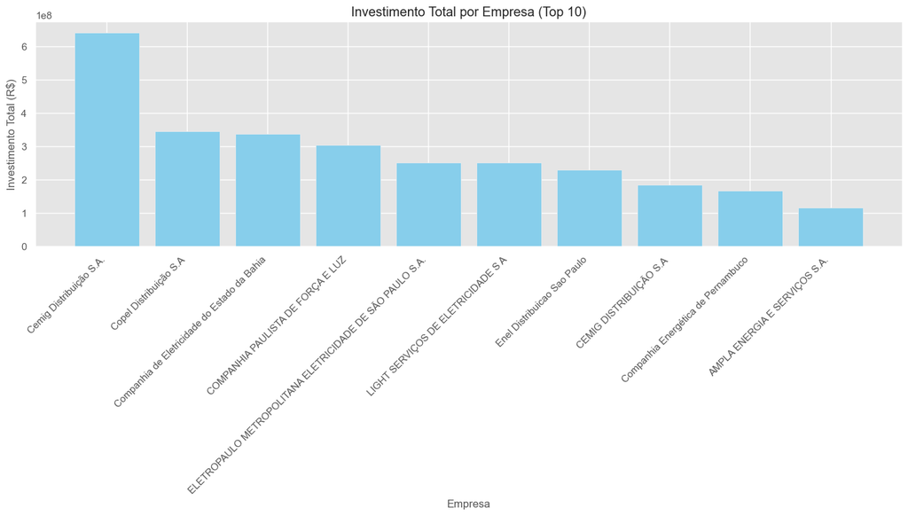

```python
# Gráfico de Barras: Investimento Total por Empresa
plt.figure(figsize=(14, 8))
plt.bar(projetos_por_empresa.index[:10], projetos_por_empresa['TotalCusto'][:10], color='skyblue')
plt.title('Investimento Total por Empresa (Top 10)')
plt.xlabel('Empresa')
plt.ylabel('Investimento Total (R$)')
plt.xticks(rotation=45, ha='right')
plt.tight_layout()
plt.show()
```

### Análise do Gráfico de Dispersão: Investimento vs. Economia de Energia

O gráfico de dispersão que analisamos abaixo mostra a relação entre o **investimento total em eficiência energética** (`VlrCustoTotal`) e a **energia economizada** (`VlrEnergiaEconomizadaTotal`).

#### Observações do Gráfico

- Observamos que **vários pontos com investimentos menores** têm uma **economia de energia relativamente alta**.
- Isso pode indicar que algumas empresas são mais **eficientes** em seus projetos de eficiência energética, conseguindo **maximizar a economia com menor investimento**.
- Esta tendência também sugere que fatores como **o tipo de equipamento utilizado** ou **a qualidade da implementação** dos projetos podem ter um papel significativo na economia de energia, não sendo apenas o valor investido o determinante.

#### Revisão dos Dados

Com base nos **dicionários dos arquivos CSV e PDFs fornecidos**:

- **Tipologia e Tipo de Equipamento**: O tipo de tecnologia utilizada (`DscTipoEquipamento`) pode ser um fator importante para explicar a alta eficiência de algumas empresas. Projetos que utilizaram **equipamentos mais modernos e eficientes**, como iluminação LED, tendem a apresentar **economias maiores**.
- **Uso Final da Energia**: Projetos voltados para **áreas específicas de uso**, como **residencial ou industrial**, podem ter resultados distintos. Isso deve ser considerado ao interpretar a eficiência dos projetos.

```
Correlação entre Investimento e Economia de Energia:
                            VlrCustoTotal  VlrEnergiaEconomizadaTotal
VlrCustoTotal                    1.000000                    0.151583
VlrEnergiaEconomizadaTotal       0.151583                    1.000000
```

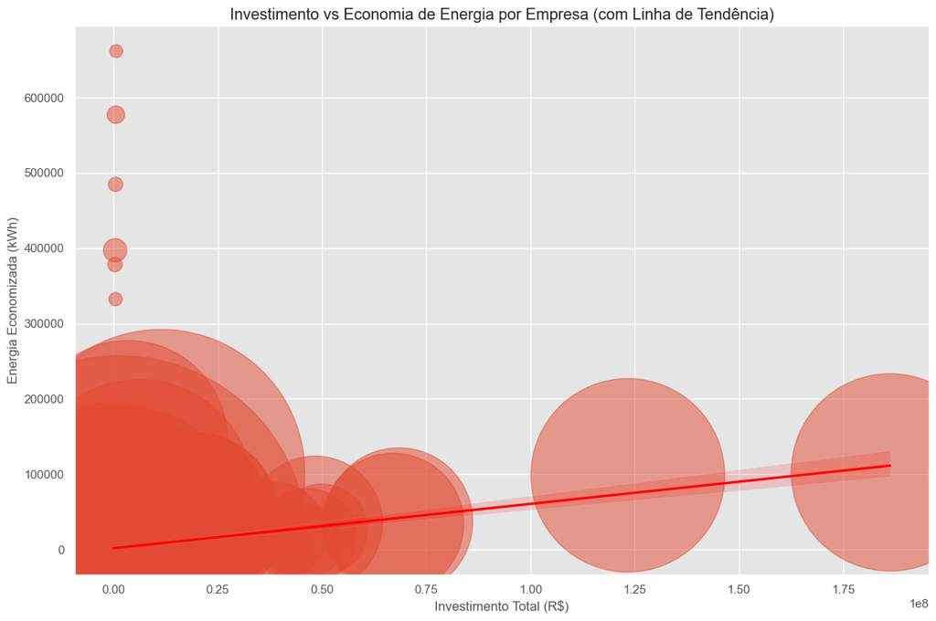

```python
# Análise de Correlação entre Investimento e Economia de Energia
correlacao = empresa_data[['VlrCustoTotal', 'VlrEnergiaEconomizadaTotal']].corr()
print("Correlação entre Investimento e Economia de Energia:")
print(correlacao)

# Gráfico de dispersão com linha de tendência para melhor visualização da relação
plt.figure(figsize=(12, 8))
sns.regplot(
    data=empresa_data,
    x='VlrCustoTotal',
    y='VlrEnergiaEconomizadaTotal',
    scatter_kws={'s': empresa_data['VlrRetiradaDemandaPontaTotal'] * 2, 'alpha': 0.5},
    line_kws={'color': 'red'}
)
plt.title('Investimento vs Economia de Energia por Empresa (com Linha de Tendência)')
plt.xlabel('Investimento Total (R$)')
plt.ylabel('Energia Economizada (kWh)')
plt.grid(True)
plt.tight_layout()
plt.show()
```

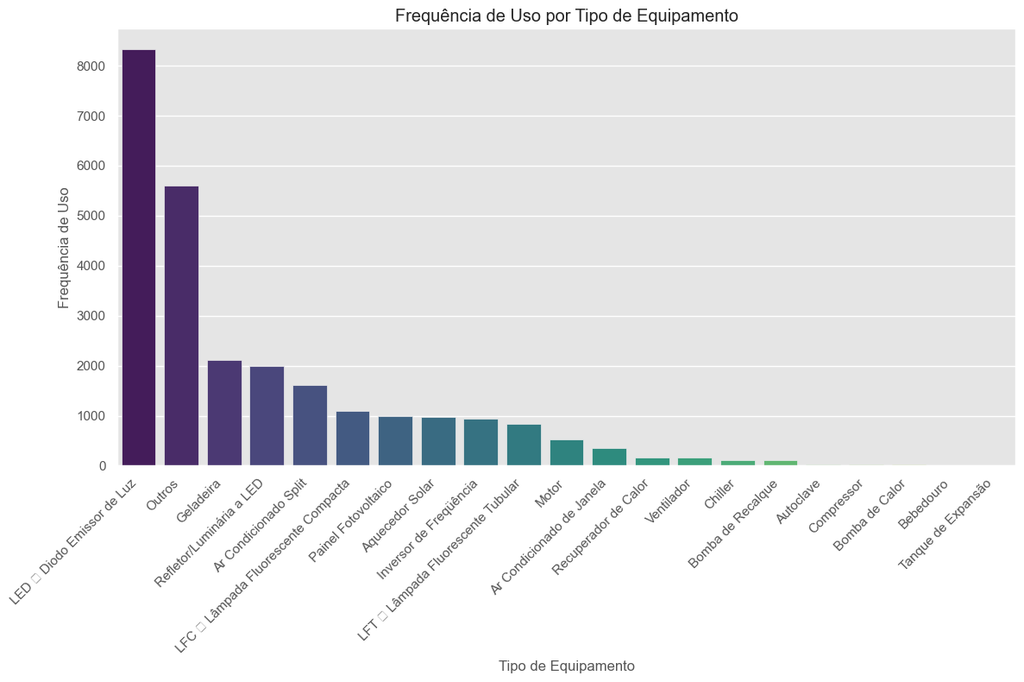

```python
import matplotlib.pyplot as plt
import seaborn as sns

# Agrupar e contar o uso dos tipos de equipaento
equipamento_frequencia = equipamento_data['DscTipoEquipamento'].value_counts()

# Plotar o gráfico de barras
plt.figure(figsize=(12, 8))
sns.barplot(x=equipamento_frequencia.index, y=equipamento_frequencia.values, palette='viridis')
plt.title('Frequência de Uso por Tipo de Equipamento')
plt.xlabel('Tipo de Equipamento')
plt.ylabel('Frequência de Uso')
plt.xticks(rotation=45, ha='right')
plt.tight_layout()
plt.show()
```

### Insights Práticos

A partir da análise, podemos destacar alguns insights importantes:

#### Inovação e Crescimento Econômico

- Empresas com maiores investimentos em eficiência energética indicam potenciais parceiros para desenvolvimento tecnológico e inovação.
- Incentivar colaborações com essas empresas pode promover soluções tecnológicas mais eficazes e fomentar novas tecnologias sustentáveis.

#### Justiça Social

- Projetos que atendem a comunidades de baixa renda devem ser ampliados para garantir benefícios econômicos e acesso equitativo à eficiência energética.

#### Preservação Ambiental

- A energia economizada contribui diretamente para a redução de emissões de carbono, promovendo uma matriz energética mais limpa e sustentável.

#### Transição para Fontes Sustentáveis

- A adoção crescente de tecnologias como iluminação LED e refrigeração eficiente aponta para a modernização dos equipamentos e o uso racional da energia.

### Conclusão

Nesta análise exploratória, utilizamos técnicas de estatística descritiva e visualização de dados para entender os padrões de consumo energético e as oportunidades de eficiência. Os insights obtidos ajudam a orientar decisões que promovam inovações tecnológicas, justiça social e preservação ambiental no setor energético brasileiro.

### Próximos Passos

#### Análise de Correlação

- Realizar uma análise de correlação entre variáveis, como custo do projeto e economia de energia, para identificar fatores críticos de sucesso.

#### Modelagem Preditiva

- Desenvolver um modelo preditivo para prever impactos futuros dos projetos com base em dados históricos, auxiliando na tomada de decisões mais precisas.

#### Análise de Clusters

- Agrupar projetos similares para definir estratégias mais direcionadas e identificar padrões comuns de sucesso em eficiência energética.

#### Relatório Detalhado e Apresentação

- Compilar os resultados da análise em um relatório detalhado para stakeholders e criar apresentações para facilitar a comunicação dos insights.

#### Política de Incentivos e Recomendações

- Sugerir recomendações de políticas de incentivo à eficiência energética focadas em áreas com maior potencial de economia e impacto social positivo.

#### Monitoramento Contínuo

- Desenvolver um plano de monitoramento contínuo para garantir a eficácia dos projetos de eficiência energética e ajustar estratégias conforme necessário.

### Insights Práticos

A partir da análise, podemos destacar alguns insights importantes:

#### Inovação e Crescimento Econômico

- Empresas com maiores investimentos em eficiência energética indicam potenciais parceiros para desenvolvimento tecnológico e inovação.
- Incentivar colaborações com essas empresas pode promover soluções tecnológicas mais eficazes e fomentar novas tecnologias sustentáveis.

#### Justiça Social

- Projetos que atendem a comunidades de baixa renda devem ser ampliados para garantir benefícios econômicos e acesso equitativo à eficiência energética.

#### Preservação Ambiental

- A energia economizada contribui diretamente para a redução de emissões de carbono, promovendo uma matriz energética mais limpa e sustentável.

#### Transição para Fontes Sustentáveis

- A adoção crescente de tecnologias como iluminação LED e refrigeração eficiente aponta para a modernização dos equipamentos e o uso racional da energia.

### Conclusão

Nesta análise exploratória, utilizamos técnicas de estatística descritiva e visualização de dados para entender os padrões de consumo energético e as oportunidades de eficiência. Os insights obtidos ajudam a orientar decisões que promovam inovações tecnológicas, justiça social e preservação ambiental no setor energético brasileiro.

### Próximos Passos

#### Análise de Correlação

- Realizar uma análise de correlação entre variáveis, como custo do projeto e economia de energia, para identificar fatores críticos de sucesso.

#### Modelagem Preditiva

- Desenvolver um modelo preditivo para prever impactos futuros dos projetos com base em dados históricos, auxiliando na tomada de decisões mais precisas.

#### Análise de Clusters

- Agrupar projetos similares para definir estratégias mais direcionadas e identificar padrões comuns de sucesso em eficiência energética.

#### Relatório Detalhado e Apresentação

- Compilar os resultados da análise em um relatório detalhado para stakeholders e criar apresentações para facilitar a comunicação dos insights.

#### Política de Incentivos e Recomendações

- Sugerir recomendações de políticas de incentivo à eficiência energética focadas em áreas com maior potencial de economia e impacto social positivo.

#### Monitoramento Contínuo

- Desenvolver um plano de monitoramento contínuo para garantir a eficácia dos projetos de eficiência energética e ajustar estratégias conforme necessário.